# Multistrain cluster monitoring

# ——————————————————————————–

```r
campy_data <- c("MergedFinal_332calls_4203genomes_clusters.tsv", #"timepoint1_synthetic.tsv",
                "MergedFinal_332calls_5075genomes_clusters.tsv")

X <- 1
Y <- 2

timepoint1 <- read.csv(file = campy_data[1], numerals = "no.loss",
                       stringsAsFactors = FALSE, sep = "\t") %>% as_tibble()
colnames(timepoint1) %<>% gsub(pattern = "genome", replacement = "isolate", x = .) %>%
  gsub(pattern = "X", replacement = "h_", x = .)

timepoint2 <- read.csv(file = campy_data[2], numerals = "no.loss",
                       stringsAsFactors = FALSE, sep = "\t") %>% as_tibble()
colnames(timepoint2) %<>% gsub(pattern = "genome", replacement = "isolate", x = .) %>%
  gsub(pattern = "X", replacement = "h_", x = .)
```

```r
# These are the isolates with designated clusters and corresponding cluster sizes at time point `r X`, for all heights.
sizes_for_tpX <- clusterSizes(timepoint1)
tpX <- isolateClusterSize(timepoint1, sizes_for_tpX) %>%
  set_colnames(c("isolate", "heights", "tpX_clusters", "tpX_sizes"))
```

```r
# These are the isolates with designated clusters and corresponding cluster sizes at time point `r Y`, for all heights.
sizes_for_tpY <- clusterSizes(timepoint2)
tpY <- isolateClusterSize(timepoint2, sizes_for_tpY) %>%
  set_colnames(c("isolate", "heights", "tpY_clusters", "tpY_sizes"))
```

Some isolates occur in only one of the two time point datasets, so the following is to keep track of this.

```r
# setting up dataframe
d <- c(timepoint1$isolate, timepoint2$isolate) %>% unique() %>%
  tibble(Isolates = ., TPX = FALSE, TPY = FALSE, Both = FALSE)

# identifying isolates in one or both
d$TPY[which(d$Isolates %in% timepoint2$isolate)] <- TRUE
d$TPX[which(d$Isolates %in% timepoint1$isolate)] <- TRUE
d$Both[which(d$TPX & d$TPY)] <- TRUE

# preparing dataset for display
d <- d[order(d$Isolates),]
d$Isolates <- unique(d$Isolates) %>% sort() %>% factor(d$Isolates, levels = .)

d$TPX %<>% as.character()
d$TPY %<>% as.character()
d$Both %<>% as.character()
vals <- c("True", "False")

d[d == "TRUE"] <- vals[1]
d[d == "FALSE"] <- vals[2]

# table with colorful cells indicating where isolates are found
d %>% set_colnames(c("Isolates", paste0("Found in time point ", X, " dataset"),
                     paste0("Found in time point ", Y, " dataset"), "Found in both datasets")) %>%
  DT::datatable(., fillContainer = TRUE, filter = "top", rownames = TRUE,
                options = list(pageLength = nrow(d), dom = "ti", scrollY = "500px")) %>%
  formatStyle(2, backgroundColor = styleEqual(vals, c("lightsteelblue", "gray"))) %>%
  formatStyle(3, backgroundColor = styleEqual(vals, c("lightgreen", "gray"))) %>%
  formatStyle(4, backgroundColor = styleEqual(vals, c("lightsteelblue", "gray")))
```

|  | Isolates | Found in time point 1 dataset | Found in time point 2 dataset | Found in both datasets |
| --- | --- | --- | --- | --- |
| 1 | 00_2427 | True | True | True |
| 2 | 00_2428 | True | True | True |
| 3 | 00_2533 | True | True | True |
| 4 | 00_2842 | True | True | True |
| 5 | 00_2853 | True | True | True |
| 6 | 00_2861 | True | True | True |
| 7 | 00_3084 | True | True | True |
| 8 | 00_3086 | True | True | True |
| 9 | 00_3451 | True | True | True |
| 10 | 00_5077 | True | True | True |

[output cut: 5065 more lines]

### Filtered to show only novel genomes

```r
d[which(d$TPX == "False"),] %>%
  set_colnames(c("Isolates", paste0("Found in time point ", X, " dataset"),
                     paste0("Found in time point ", Y, " dataset"), "Found in both datasets")) %>%
  DT::datatable(., fillContainer = TRUE, filter = "top", rownames = TRUE,
                options = list(pageLength = nrow(d), dom = "ti", scrollY = "500px")) %>%
  formatStyle(2, backgroundColor = styleEqual(vals, c("lightsteelblue", "gray"))) %>%
  formatStyle(3, backgroundColor = styleEqual(vals, c("lightgreen", "gray"))) %>%
  formatStyle(4, backgroundColor = styleEqual(vals, c("lightsteelblue", "gray")))
```

|  | Isolates | Found in time point 1 dataset | Found in time point 2 dataset | Found in both datasets |
| --- | --- | --- | --- | --- |
| 1 | 00_6197 | False | True | False |
| 2 | 06_2858 | False | True | False |
| 3 | 06_2862 | False | True | False |
| 4 | 06_2866 | False | True | False |
| 5 | 06_2874 | False | True | False |
| 6 | 06_7655 | False | True | False |
| 7 | 07_6215 | False | True | False |
| 8 | 07_7786 | False | True | False |
| 9 | 08_0086 | False | True | False |
| 10 | 12_098829_0022 | False | True | False |

[output cut: 862 more lines]

```r
# isolates at time point 2 and not time point 1
isolates_t2 <- d$Isolates[which(d$TPX == "False")] %>% as.character()
# isolates at time point 1
isolates_t1 <- d$Isolates[which(d$TPX == "True")] %>% as.character()
```

Want to find the first threshold where a new genome (added at time point 2) is part of a multistrain cluster that includes genomes from time point 1.

1. isolate_k is the k-th isolate of those that are introduced at time point 2
2. we filter the time point 2 dataset to only contain isolate_k and all height-cluster pairs where isolate_k is found in a cluster of size > 1
   - we call this filtered dataset the “candidate set”
3. then for each row of the candidate set (each height-cluster pair), we filter the time point 2 dataset to show all isolates found in the selected cluster at the selected height - “candidate isolates”
   - if any of these isolates were present in the time point 1 dataset, we return isolate_k-height-cluster as a success
   - if none of the isolates were present in the time point 1 dataset, we move onto the next height-cluster pair in the candidate set

```r
print("Identifying isolates found at both TP1 and TP2 ...")
set3 <- lapply(colnames(timepoint2)[-1], function(h) {
  set1 <- timepoint2 %>% filter(isolate %in% isolates_t1) %>% dplyr::select(all_of(h)) %>% unique()
  set2 <- timepoint2 %>% filter(isolate %in% isolates_t2) %>% dplyr::select(all_of(h)) %>% unique()
  intersect(set1, set2) %>% unlist(., use.names = FALSE) %>% return()
}) %>% set_names(colnames(timepoint2)[-1])

print("Generating a dataset where we only keep clusters that have isolates at both TP1 and TP2 ...")
tmp <- lapply(names(set3), function(h) {
  tpY %>% filter(heights == h) %>% filter(tpY_clusters %in% set3[[h]]) %>% return()
}) %>% bind_rows()

print("Finding the first heights at which each novel genome is absorbed into an existing cluster ...")
novel_absorbed_init <- lapply(1:length(isolates_t2), function(k) {
  isolate_k <- isolates_t2[k]
  tmp %>% filter(isolate %in% isolate_k) %>% filter(tpY_sizes > 1) %>% head(., 1) %>% return()
}) %>% bind_rows() %>% set_colnames(c("isolate", "heights", "clusters", "cluster_sizes"))
```

## Novel Genome Absorption

```r
novel_absorbed <- novel_absorbed_init
novel_absorbed$h <- lapply(novel_absorbed$heights, function(h) strsplit(h, split = "_") %>% unlist() %>%
                 extract2(2) %>% as.numeric) %>% unlist()

novel_absorbed$isolates_num <- 1:nrow(novel_absorbed)

novel_absorbed <- novel_absorbed[,c("isolates_num", "isolate", "heights", "h", "clusters", "cluster_sizes")] %>%
  set_colnames(c("Genome_number", "New_genome_at_T2", "Height_char",
                 "Height_num", "Cluster", "Cluster_size"))

dfx <- table(novel_absorbed$Height_char) %>% sort(., decreasing = TRUE) %>% as.data.frame() %>%
  as_tibble() %>% set_colnames(c("Height_char", "Frequency_of_height_in_table"))
dfx$Height_char %<>% as.character()

novel_absorbed <- left_join(novel_absorbed, dfx, by = "Height_char")

novel_absorbed %>% set_colnames(gsub("_", " ", colnames(novel_absorbed))) %>%
  DT::datatable(., fillContainer = TRUE, filter = "top", rownames = FALSE,
                options = list(pageLength = nrow(novel_absorbed), dom = "ti", scrollY = "500px",
                               columnDefs = list(list(className = "dt-center", targets = 0:6))))
```

| Genome number | New genome at T2 | Height char | Height num | Cluster | Cluster size | Frequency of height in table |
| --- | --- | --- | --- | --- | --- | --- |
| 1 | 00_6197 | h_0 | 0 | 1434 | 6 | 223 |
| 2 | 06_2858 | h_45 | 45 | 207 | 21 | 1 |
| 3 | 06_2862 | h_2 | 2 | 106 | 10 | 41 |
| 4 | 06_2866 | h_5 | 5 | 43 | 4 | 13 |
| 5 | 06_2874 | h_16 | 16 | 537 | 11 | 7 |
| 6 | 06_7655 | h_1 | 1 | 84 | 4 | 60 |
| 7 | 07_6215 | h_4 | 4 | 850 | 9 | 22 |
| 8 | 07_7786 | h_0 | 0 | 205 | 2 | 223 |
| 9 | 08_0086 | h_16 | 16 | 34 | 16 | 7 |
| 10 | 12_098829_0022 | h_1 | 1 | 1887 | 7 | 60 |

[output cut: 862 more lines]

### Raw data

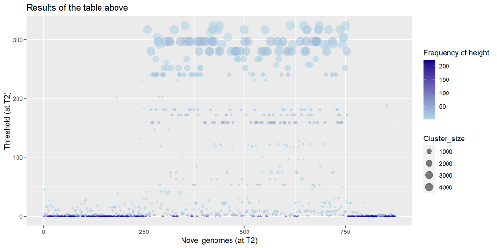

```r
h_values <- novel_absorbed$Height_char %>% table() %>% sort(., decreasing = TRUE) %>% names()

{ggplot(novel_absorbed, aes(x = Genome_number, y = Height_num,
                            size = Cluster_size, color = Frequency_of_height_in_table)) +
    geom_point(alpha = 0.5) +
    xlab("Novel genomes (at T2)") + ylab("Threshold (at T2)") +
    labs(color = "Frequency of height") +
    scale_color_gradient(low = "lightblue", high = "darkblue") +
    ggtitle(paste0("Results of the table above"))} #%>%
```

### Filtered by min and max cluster size

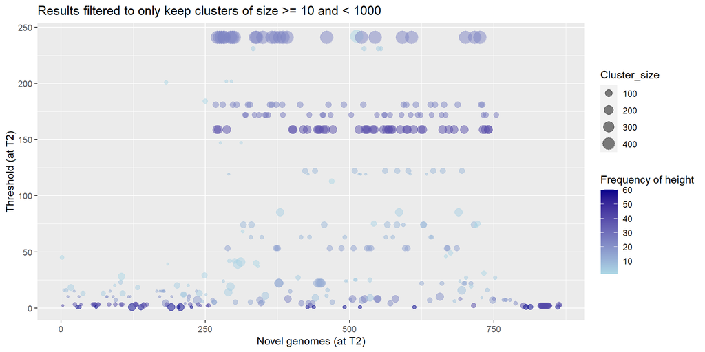

```r
min_size <- 10
max_size <- 1000
sig_clusters <- novel_absorbed %>%
  filter(Cluster_size >= min_size) %>%
  filter(Cluster_size < max_size) %>%
  filter(Height_num > 0)

h_values_filtered <- sig_clusters$Height_char %>% table() %>% sort(., decreasing = TRUE) %>% names()

# {
  ggplot(sig_clusters, aes(x = Genome_number, y = Height_num,
                           size = Cluster_size, color = Frequency_of_height_in_table)) +
    geom_point(alpha = 0.5) +
    xlab("Novel genomes (at T2)") + ylab("Threshold (at T2)") +
    labs(color = "Frequency of height") +
    scale_color_gradient(low = "lightblue", high = "darkblue") +
    ggtitle(paste0("Results filtered to only keep clusters of size >= ", min_size, " and < ", max_size))
```

```r
  # } %>%
  # ggplotly()
```

The top 10 heights in terms of novel genome absorption (when looking at clusters with sizes in [10,1000)) are, in order, **159, 172, 2, 241, 181, 3, 1, 53, 7, 10**.

## Notable results

```r
key_clusters <- novel_absorbed %>%
  dplyr::arrange(Height_num, Cluster) %>%
  dplyr::select(Height_char, Cluster) %>%
  unique()

cluster_changes <- lapply(1:nrow(key_clusters), function(i) {
  # each row is a height-cluster pair, call HC
  h <- key_clusters$Height_char[i]
  cl <- key_clusters$Cluster[i]

  # given HC, finds the corresponding isolates at TP2
  key_isolates <- timepoint2 %>% dplyr::select(isolate, all_of(h)) %>%
    set_colnames(c("isolate","h_x")) %>%
    filter(h_x == cl)# %>% pull(isolate)

  # filter TP1 dataset - using height and isolates found at TP2
  tp1_clusters <- timepoint1 %>%
    filter(isolate %in% key_isolates$isolate) %>%
    dplyr::select(any_of(h))

  # if the cluster existed at TP1, obtain "old" cluster label and size
  if (ncol(tp1_clusters) > 0) {
    orig_clusters <- tp1_clusters %>% table() %>% as_tibble() %>%
      set_colnames(c("Original_cluster","Original_cluster_size"))
    in_height <- nrow(tp1_clusters)
    orig_c_num <- nrow(orig_clusters)
  }else {
    orig_clusters <- tibble("Original_cluster" = NA, "Original_cluster_size" = NA)
    orig_c_num <- in_height <- 0
  }

  # bind original cluster data to new cluster label
  key_clusters %>% filter((Height_char %in% h) & (Cluster %in% cl)) %>%
    bind_cols(., orig_clusters, Number_original_clusters = orig_c_num,
              Total_original_cluster_size = in_height) %>% return()

}) %>% bind_rows()

df_tracked <- merge(novel_absorbed, cluster_changes, by = c("Height_char", "Cluster")) %>% as_tibble()

df_tracked$Size_dif <- df_tracked$Cluster_size - df_tracked$Original_cluster_size
df_tracked$Total_size_dif <- df_tracked$Cluster_size - df_tracked$Total_original_cluster_size

cname_ordering <- c("New_genome_at_T2", "Height_num", "Height_char",
                    "Frequency_of_height_in_table", "Cluster", "Cluster_size",
                    "Number_original_clusters", "Original_cluster", "Original_cluster_size",
                    "Total_original_cluster_size", "Size_dif", "Total_size_dif")
df_tracked <- df_tracked[,cname_ordering]
```

```r
df_tracked %>%
  arrange(Height_char, Cluster, -Size_dif) %>%
  set_colnames(c("Novel genome (at T2)", "Height (numeric)", "Height (characters)",
                 "Frequency of height in table", "Cluster", "Cluster size",
                 "Number of original clusters", "Original cluster", "Original cluster size",
                 "Total size of original clusters", "Individual cluster size differences",
                 "Total cluster size differences")) %>%
  DT::datatable(., fillContainer = TRUE, filter = "top", rownames = FALSE,
                options = list(pageLength = nrow(df_tracked), dom = "ti",
                               scrollY = "500px",
                               columnDefs = list(list(className = "dt-center", targets = 1:11))))
```

| Novel genome (at T2) | Height (numeric) | Height (characters) | Frequency of height in table | Cluster | Cluster size | Number of original clusters | Original cluster | Original cluster size | Total size of original clusters | Individual cluster size differences | Total cluster size differences |
| --- | --- | --- | --- | --- | --- | --- | --- | --- | --- | --- | --- |
| CI_5602 | 0 | h_0 | 223 | 10 | 2 | 1 | 10 | 1 | 1 | 1 | 1 |
| CI_5001 | 0 | h_0 | 223 | 14 | 8 | 1 | 14 | 7 | 7 | 1 | 1 |
| CI_4724 | 0 | h_0 | 223 | 19 | 2 | 1 | 19 | 1 | 1 | 1 | 1 |
| 13_021649_0021 | 0 | h_0 | 223 | 78 | 5 | 1 | 77 | 4 | 4 | 1 | 1 |
| 13_071934_0017 | 0 | h_0 | 223 | 90 | 2 | 1 | 84 | 1 | 1 | 1 | 1 |
| 13_070671_0018 | 0 | h_0 | 223 | 93 | 2 | 1 | 87 | 1 | 1 | 1 | 1 |
| 13_013887_0020 | 0 | h_0 | 223 | 100 | 2 | 1 | 93 | 1 | 1 | 1 | 1 |
| 13_009777_0025 | 0 | h_0 | 223 | 106 | 6 | 1 | 100 | 5 | 5 | 1 | 1 |
| CA10SH18599008201 | 0 | h_0 | 223 | 110 | 6 | 1 | 104 | 5 | 5 | 1 | 1 |
| CI_4426 | 0 | h_0 | 223 | 112 | 4 | 1 | 106 | 3 | 3 | 1 | 1 |

[output cut: 1089 more lines]

Exception to the general scenario:  
* Cluster x at TP2 contains isolates found in clusters t, u, v at TP1. Then each cluster size difference doesn’t illustrate this, and the “total cluster size change” does

- e.g.
  - consider cluster 393 found in TP2 at threshold h_29, which has size 53 (including the novel genomes and TP1 isolates)
  - the TP1 isolates in this cluster are found in three different clusters at h_29 in the TP1 dataset
  - the cluster sizes are 20, 1, and 1, respectively
  - so the individual cluster size changes are 33, 52, 52, whereas the “total change” is 31
  - we plot both, but consider the “total change” going forward.

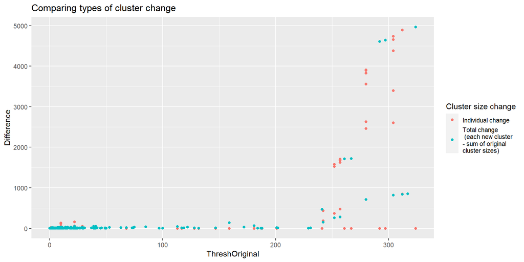

```r
change_types <- df_tracked %>% dplyr::select(Height_num, Cluster, Size_dif, Total_size_dif) %>% unique()
change_types$Height_cluster <- paste(change_types$Height_num, change_types$Cluster, sep = "-")
change_types %<>% dplyr::select(Height_num, Height_cluster, Size_dif, Total_size_dif) %>% unique() %>%
  set_colnames(c("Height_num", "Height_cluster", "Individual change",
                 "Total change\n (each new cluster \n- sum of original \ncluster sizes)")) %>%
  melt(., id.vars = c("Height_num", "Height_cluster")) %>% as_tibble() %>%
  set_colnames(c("ThreshOriginal", "ThreshOriginal_cluster", "Cluster size change", "Difference"))
change_types$Difference[is.na(change_types$Difference)] <- 0

ggplot(change_types, aes(x = ThreshOriginal, y = Difference, color = `Cluster size change`)) +
  geom_point() + ggtitle("Comparing types of cluster change")
```

Comparing the “total change” means some of the minor changes due to clustering don’t overwhelm the differences (e.g. clustered into three clusters at time point 1 and into one cluster at time point 2).

```r
all_heights<- df_tracked %>%
  dplyr::select(Height_num, Height_char, Cluster, Total_size_dif) %>%
  unique() %>% dplyr::arrange(Height_num, Cluster)

all_heights$Height_char <- factor(all_heights$Height_char,
                               levels = all_heights$Height_char[order(all_heights$Height_num)] %>% unique())

q <- ggplot(all_heights, aes(x = Height_char, y = Total_size_dif)) + geom_boxplot()
q_data <- ggplot_build(q) %>% extract2("data")
q_points <- tibble(Height_num = all_heights$Height_num %>% unique(),
                   Height_char = all_heights$Height_char %>% unique(),
                   median = q_data[[1]]$middle,
                   q3 = q_data[[1]]$upper) %>%
  melt(., id.vars = c("Height_num", "Height_char")) %>% as_tibble()
```

We’re more interested in the earlier heights:

## Cluster size differences - comparing time points

### 1-100

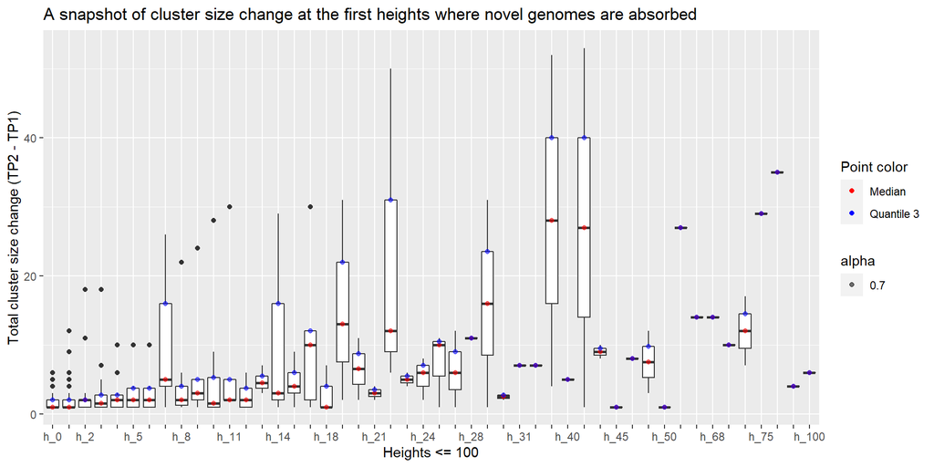

```r
snapshot1 <- all_heights %>% filter(Height_num <= 100)
p_points <- q_points %>% filter(Height_num <= 100)
ggplot(snapshot1, aes(x = Height_char, y = Total_size_dif)) +
  geom_boxplot() +
  geom_point(data = p_points, aes(x = Height_char, y = value, color = variable, alpha = 0.7)) +
  scale_x_discrete(guide = guide_axis(check.overlap = TRUE)) +
  scale_color_manual(name = "Point color", values = c("median"="red","q3"="blue"),
                       labels = c("Median", "Quantile 3")) +
  xlab(paste0("Heights <= 100")) + ylab("Total cluster size change (TP2 - TP1)") +
  ggtitle("A snapshot of cluster size change at the first heights where novel genomes are absorbed")
```

### 100-200

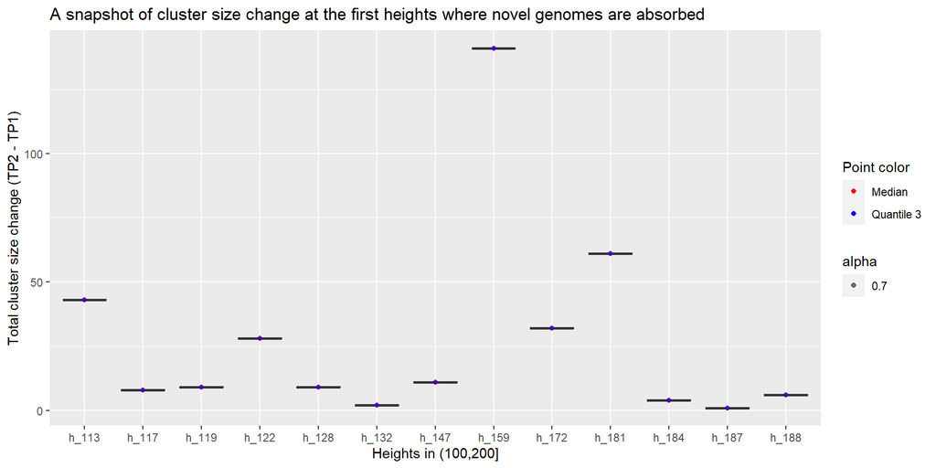

```r
snapshot1 <- all_heights %>% filter((Height_num > 100) & (Height_num <= 200))
p_points <- q_points %>% filter((Height_num > 100) & (Height_num <= 200))
ggplot(snapshot1, aes(x = Height_char, y = Total_size_dif)) +
  geom_boxplot() +
  geom_point(data = p_points, aes(x = Height_char, y = value, color = variable, alpha = 0.7)) +
  scale_x_discrete(guide = guide_axis(check.overlap = TRUE)) +
  scale_color_manual(name = "Point color", values = c("median"="red","q3"="blue"),
                       labels = c("Median", "Quantile 3")) +
  xlab(paste0("Heights in (100,200]")) + ylab("Total cluster size change (TP2 - TP1)") +
  ggtitle("A snapshot of cluster size change at the first heights where novel genomes are absorbed")
```

### 200-

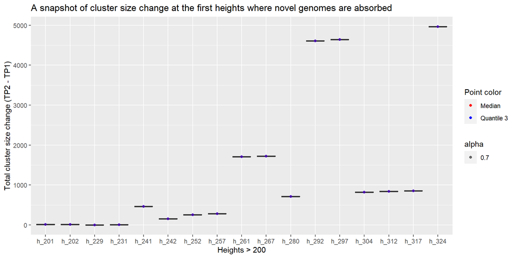

```r
snapshot1 <- all_heights %>% filter((Height_num > 200))
p_points <- q_points %>% filter(Height_num > 200)
ggplot(snapshot1, aes(x = Height_char, y = Total_size_dif)) +
  geom_boxplot() +
  geom_point(data = p_points, aes(x = Height_char, y = value, color = variable, alpha = 0.7)) +
  scale_x_discrete(guide = guide_axis(check.overlap = TRUE)) +
  scale_color_manual(name = "Point color", values = c("median"="red","q3"="blue"),
                       labels = c("Median", "Quantile 3")) +
  xlab(paste0("Heights > 200")) + ylab("Total cluster size change (TP2 - TP1)") +
  ggtitle("A snapshot of cluster size change at the first heights where novel genomes are absorbed")
```

### All heights

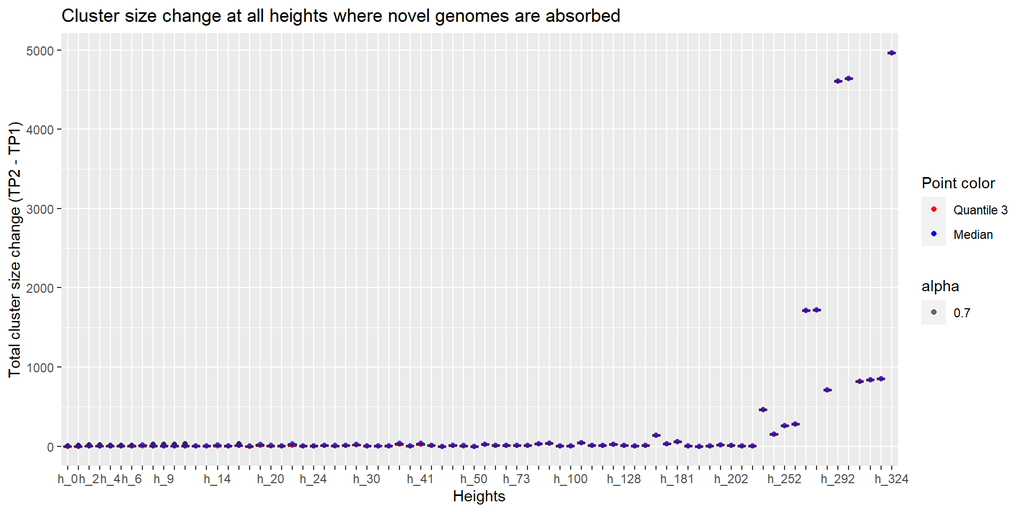

```r
ggplot(all_heights, aes(x = Height_char, y = Total_size_dif)) +
  geom_boxplot() +
  geom_point(data = q_points, aes(x = Height_char, y = value, color = variable, alpha = 0.7)) +
  scale_x_discrete(guide = guide_axis(check.overlap = TRUE)) +
  scale_color_manual(name = "Point color", values = c("median"="red","q3"="blue"),
                       labels = c("Quantile 3", "Median")) +
  xlab(paste0("Heights")) + ylab("Total cluster size change (TP2 - TP1)") +
  ggtitle("Cluster size change at all heights where novel genomes are absorbed")
```

## Cluster sizes across heights (not differences) - comparing timepoints

```r
# df_h <- tibble(h = lapply(h_values, function(h) substr(h, 3, nchar(h))) %>% unlist() %>% as.numeric(),
#                heights = h_values, t1 = NA, t2 = NA, both = NA)
# df_h$t1[which(df_h$heights %in% colnames(timepoint1))] <- 1
# df_h$t2[which(df_h$heights %in% colnames(timepoint2))] <- 2
# df_h$both <- df_h$t1 + df_h$t2
# df_h <- df_h[!is.na(df_h$both),] %>% dplyr::arrange(h) %>% filter(h <= 100)
#
# t1 <- sizes_for_tpX %>% dplyr::select(cluster, df_h$heights) %>%
#   melt(., id.vars = "cluster") %>% as_tibble() %>%
#   add_column(dataset = "timepoint1", .after = "cluster")
#
# t2 <- sizes_for_tpY %>% dplyr::select(cluster, df_h$heights) %>%
#   melt(., id.vars = "cluster") %>% as_tibble() %>%
#   add_column(dataset = "timepoint2", .after = "cluster")
#
# both <- bind_rows(t1, t2)
# both$dataset <- factor(both$dataset, labels = c("timepoint1", "timepoint2"))
#
# ggplot(both, aes(x = variable, y = value, fill = dataset)) +
#   geom_boxplot() + xlab("Heights") + ylab("Cluster sizes")
```

```r
cluster_difs <- df_tracked %>% dplyr::select(Height_num, Height_char, Cluster, Cluster_size,
                                             Number_original_clusters, Original_cluster,
                                             Original_cluster_size, Total_original_cluster_size,
                                             Size_dif, Total_size_dif) %>% unique()

a <- cluster_difs %>% dplyr::select(Height_num, Height_char, Cluster, Cluster_size) %>%
  unique() %>% dplyr::arrange(Height_num, Cluster) %>%
  add_column(dataset = "timepoint1", .before = "Height_num")

b <- cluster_difs %>% dplyr::select(Height_num, Height_char, Original_cluster, # Original_cluster_size,
                                    Total_original_cluster_size) %>%
  unique() %>% dplyr::arrange(Height_num, Original_cluster) %>%
  add_column(dataset = "timepoint2", .before = "Height_num") %>%
  set_colnames(colnames(a))

b$Cluster %<>% as.double()
b$Cluster_size %<>% as.integer()

new_set <- bind_rows(a,b) %>% dplyr::arrange(Height_num, dataset, Cluster)
x <- new_set$Height_char
new_set$Height_char <- factor(x, levels = x[order(new_set$Height_num)] %>% unique())
```

### 1-100

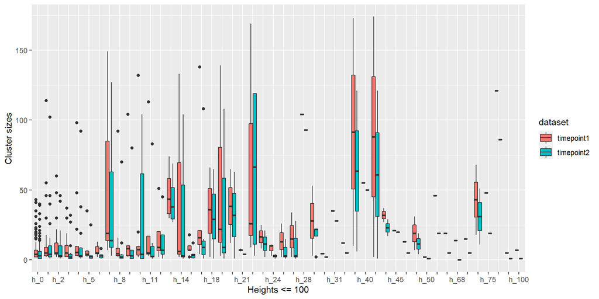

```r
part1 <- new_set %>% filter(Height_num <= 100)
ggplot(part1, aes(x = Height_char, y = Cluster_size, fill = dataset)) +
  geom_boxplot() + xlab("Heights <= 100") + ylab("Cluster sizes") +
  scale_x_discrete(guide = guide_axis(check.overlap = TRUE))
```

### 100-200

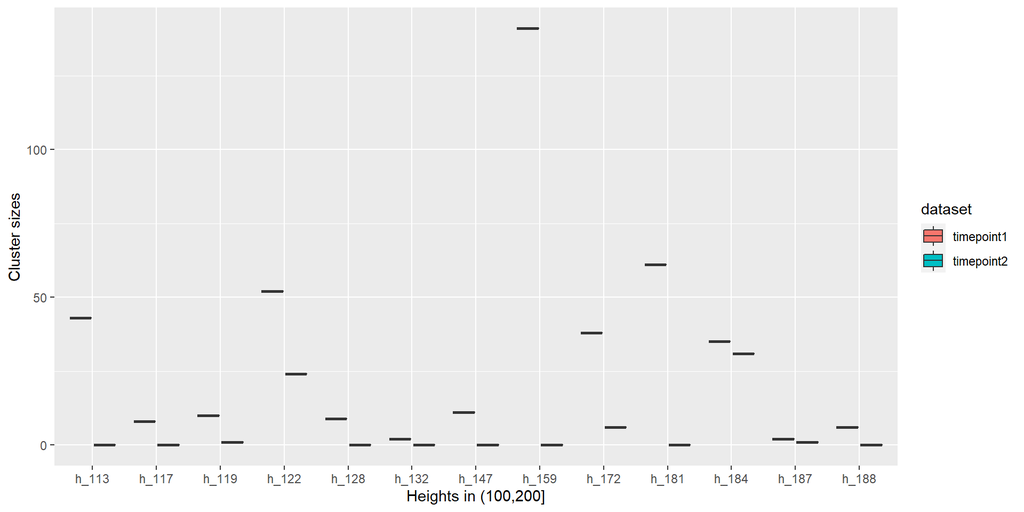

```r
part2 <- new_set %>% filter((Height_num > 100) & (Height_num <= 200))
ggplot(part2, aes(x = Height_char, y = Cluster_size, fill = dataset)) +
  geom_boxplot() + xlab("Heights in (100,200]") + ylab("Cluster sizes") +
  scale_x_discrete(guide = guide_axis(check.overlap = TRUE))
```

### 200-

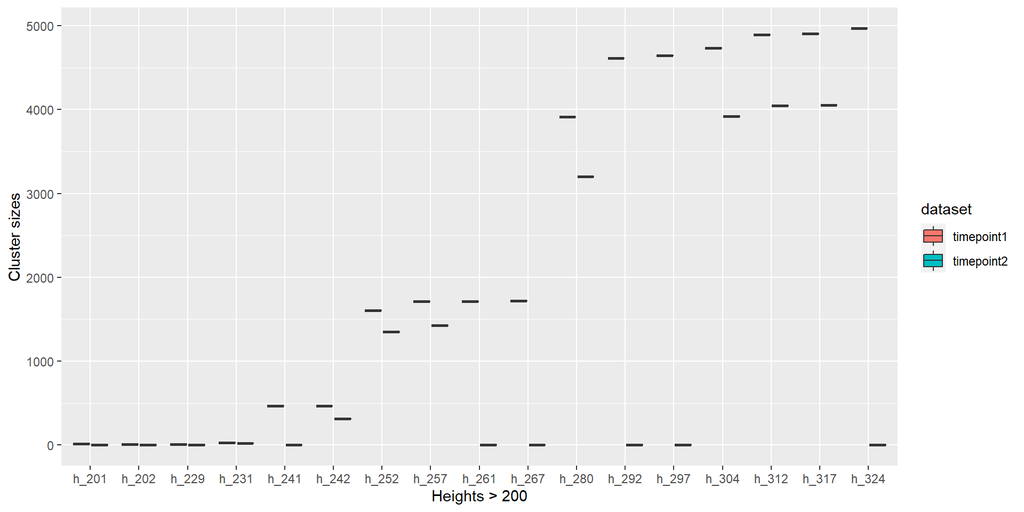

```r
part3 <- new_set %>% filter(Height_num > 200)
ggplot(part3, aes(x = Height_char, y = Cluster_size, fill = dataset)) +
  geom_boxplot() + xlab("Heights > 200") + ylab("Cluster sizes") +
  scale_x_discrete(guide = guide_axis(check.overlap = TRUE))
```

### All heights

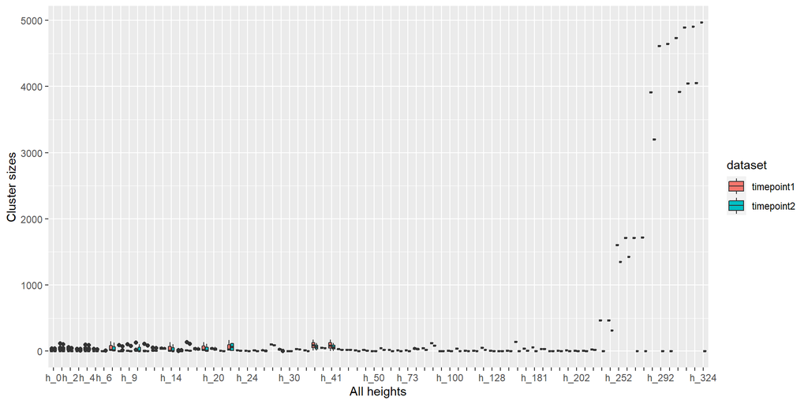

```r
ggplot(new_set, aes(x = Height_char, y = Cluster_size, fill = dataset)) +
  geom_boxplot() + xlab("All heights") + ylab("Cluster sizes") +
  scale_x_discrete(guide = guide_axis(check.overlap = TRUE))
```

## Changes in cluster size when genomes are added (at notable heights <= 150). I.e. **Results!**

```r
notable_change <- all_heights %>% filter(Height_num <= 150) %>%
  dplyr::arrange(-Total_size_dif) %>%
  dplyr::select(Height_char, Cluster, Total_size_dif) %>%
  set_colnames(c("Threshold", "Cluster", "Size change"))

# brks <- c(0,10,20,30,40,50)#quantile(notable_change$`Size change`)
# clrs <- round(seq(255, 40, length.out = length(brks) + 1), 0) %>%
#   {paste0("rgb(", .,",", 105, ",255)")}
notable_change %>%
  DT::datatable(., fillContainer = TRUE, filter = "top", rownames = TRUE,
                options = list(pageLength = nrow(notable_change), dom = "ti", scrollY = "500px",
                               columnDefs = list(list(className = "dt-center", targets = 0:3))))
```

|  | Threshold | Cluster | Size change |
| --- | --- | --- | --- |
| 1 | h_41 | 216 | 53 |
| 2 | h_39 | 221 | 52 |
| 3 | h_22 | 266 | 50 |
| 4 | h_113 | 128 | 43 |
| 5 | h_85 | 199 | 35 |
| 6 | h_19 | 274 | 31 |
| 7 | h_29 | 393 | 31 |
| 8 | h_11 | 668 | 30 |
| 9 | h_16 | 290 | 30 |
| 10 | h_14 | 309 | 29 |

[output cut: 380 more lines]

```r
  # formatStyle("Size change", target = 'row', backgroundColor = styleInterval(brks, clrs))
```

## Identifying the distribution of the cluster size changes

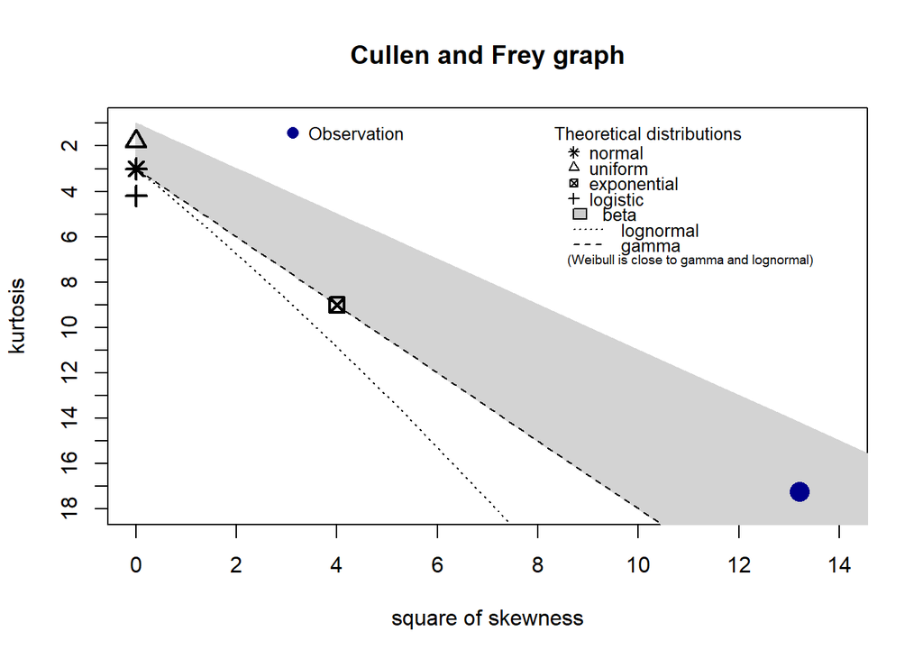

```
## summary statistics
## ------
## min:  2   max:  174
## median:  5
## mean:  15.04178
## estimated sd:  27.34075
## estimated skewness:  3.634593
## estimated kurtosis:  17.23527
```

```r
a <- part1 %>% filter(dataset == "timepoint1")
b <- part1 %>% filter(dataset == "timepoint2")
x <- a %>% pull(Cluster_size)
# hist(x)
descdist(x)
```

## General method for datasets: a more manual approach for “traditional” distributions

### Normal

```r
fit_norm <- fitdist(x, "norm", method = "mge")
```

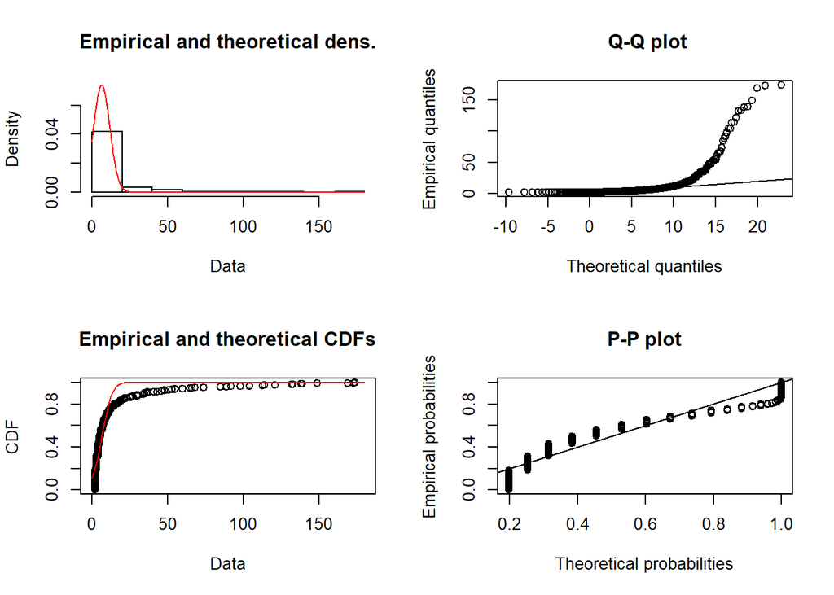

```r
plot(fit_norm)
```

### Weibull

```r
fit_weibull <- fitdist(x,  distr = "weibull", method = "mge")
```

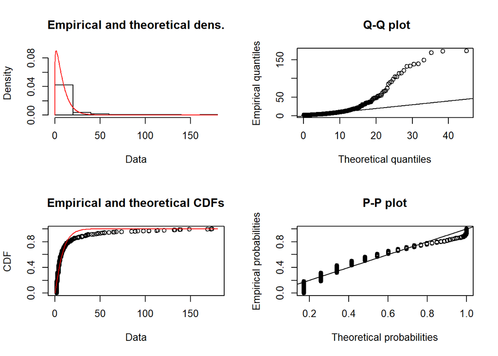

```r
plot(fit_weibull)
```

### Exponential

```r
fit_exp <- fitdist(x, "exp", method = "mge")
```

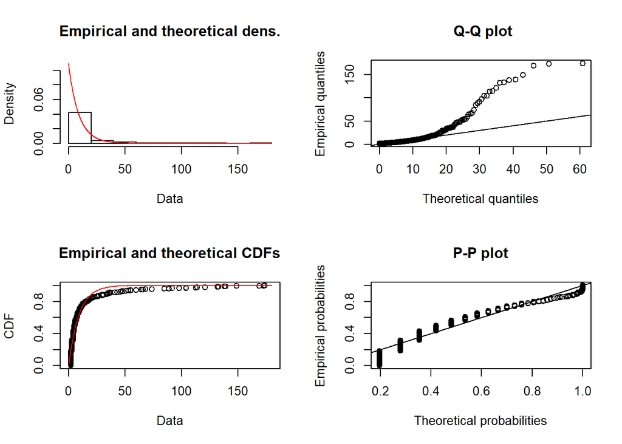

```r
plot(fit_exp)
```

### Gamma

```r
fit_gamma <- fitdist(x, "gamma", method = "mge")
```

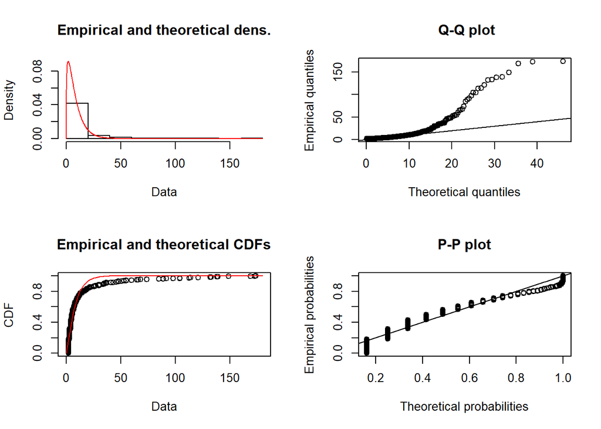

```r
plot(fit_gamma)
```

### Lognormal

```r
fit_lnorm <- fitdist(x, "lnorm", method = "mge")
```

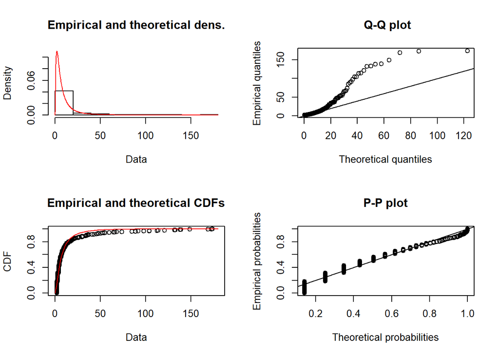

```r
plot(fit_lnorm)
```

### Uniform

```r
fit_unif <- fitdist(x, "unif", method = "mge")
```

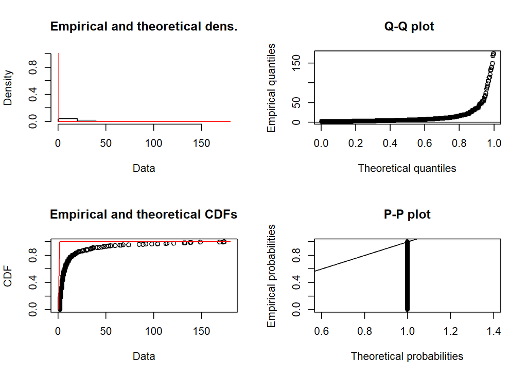

```r
plot(fit_unif)
```

```r
fitted_models <- list(fit_norm, fit_weibull, fit_exp,
                      fit_gamma, fit_lnorm, fit_unif) %>%
  set_names(c("Normal", "Weibull", "Exponential",
              "Gamma", "Lognormal", "Uniform"))

aics <- c(fit_norm$aic, fit_weibull$aic, fit_exp$aic,
          fit_gamma$aic, fit_lnorm$aic, fit_unif$aic) %>%
  set_names(c("Normal", "Weibull", "Exponential",
              "Gamma", "Lognormal", "Uniform"))

best_fit_name <- which.min(aics) %>% names()
as.data.frame(aics) %>% rownames_to_column() %>% as_tibble() %>%
  set_colnames(c("Distribution", "AIC")) %>% kable()
```

| Distribution | AIC |
| --- | --- |
| Normal | 12740.044 |
| Weibull | 3245.310 |
| Exponential | 2956.680 |
| Gamma | 3147.730 |
| Lognormal | 2657.067 |
| Uniform | Inf |

The lognormal has the lowest AIC, so that distribution might be an adequate fit. Now we try a goodness of fit test to verify.

```r
gofTest(x, test = "cvm", distribution = "lnorm")
```

```
##
## Results of Goodness-of-Fit Test
## -------------------------------
##
## Test Method:                     Cramer-von Mises GOF
##
## Hypothesized Distribution:       Lognormal
##
## Estimated Parameter(s):          meanlog = 1.936496
##                                  sdlog   = 1.094240
##
## Estimation Method:               mvue
##
## Data:                            x
##
## Sample Size:                     383
##
## Test Statistic:                  W = 1.513797
##
## Test Statistic Parameter:        n = 383
##
## P-value:                         7.37e-10
##
## Alternative Hypothesis:          True cdf does not equal the
##                                  Lognormal Distribution.
```